# Exploratory Data Analysis For Student Alcohol Consumption

TiewKH

December 2016

## Libraries and loading the .csv file

The dataset for this EDA can be found at https://www.kaggle.com/uciml/student-alcohol-consumption

The .csv file we chose to explore is student-mat.csv

```r
library(ggplot2)
library(plotly)
library(gridExtra)
library(reshape2)
library(plyr)
library(dplyr)
df <- read.csv("student-mat.csv", header = TRUE)
```

## Preprocessing - Checking For Special Values

We used a function to check if the values in the dataset contain any special values. After running the function, we found out that there were no special values in the entire dataset. Thus, no cleaning is required.

```r
is.special <- function(x){
  if (is.numeric(x)) !is.finite(x) else is.na(x)
}
head((data.frame(sapply(df, is.special))))
```

```
##   school   sex   age address famsize Pstatus  Medu  Fedu  Mjob  Fjob
## 1  FALSE FALSE FALSE   FALSE   FALSE   FALSE FALSE FALSE FALSE FALSE
## 2  FALSE FALSE FALSE   FALSE   FALSE   FALSE FALSE FALSE FALSE FALSE
## 3  FALSE FALSE FALSE   FALSE   FALSE   FALSE FALSE FALSE FALSE FALSE
## 4  FALSE FALSE FALSE   FALSE   FALSE   FALSE FALSE FALSE FALSE FALSE
## 5  FALSE FALSE FALSE   FALSE   FALSE   FALSE FALSE FALSE FALSE FALSE
## 6  FALSE FALSE FALSE   FALSE   FALSE   FALSE FALSE FALSE FALSE FALSE
##   reason guardian traveltime studytime failures schoolsup famsup  paid
## 1  FALSE    FALSE      FALSE     FALSE    FALSE     FALSE  FALSE FALSE
## 2  FALSE    FALSE      FALSE     FALSE    FALSE     FALSE  FALSE FALSE
## 3  FALSE    FALSE      FALSE     FALSE    FALSE     FALSE  FALSE FALSE
## 4  FALSE    FALSE      FALSE     FALSE    FALSE     FALSE  FALSE FALSE
## 5  FALSE    FALSE      FALSE     FALSE    FALSE     FALSE  FALSE FALSE
## 6  FALSE    FALSE      FALSE     FALSE    FALSE     FALSE  FALSE FALSE
##   activities nursery higher internet romantic famrel freetime goout  Dalc
## 1      FALSE   FALSE  FALSE    FALSE    FALSE  FALSE    FALSE FALSE FALSE
## 2      FALSE   FALSE  FALSE    FALSE    FALSE  FALSE    FALSE FALSE FALSE
## 3      FALSE   FALSE  FALSE    FALSE    FALSE  FALSE    FALSE FALSE FALSE
## 4      FALSE   FALSE  FALSE    FALSE    FALSE  FALSE    FALSE FALSE FALSE
## 5      FALSE   FALSE  FALSE    FALSE    FALSE  FALSE    FALSE FALSE FALSE
## 6      FALSE   FALSE  FALSE    FALSE    FALSE  FALSE    FALSE FALSE FALSE
##    Walc health absences    G1    G2    G3
## 1 FALSE  FALSE    FALSE FALSE FALSE FALSE
## 2 FALSE  FALSE    FALSE FALSE FALSE FALSE
## 3 FALSE  FALSE    FALSE FALSE FALSE FALSE
## 4 FALSE  FALSE    FALSE FALSE FALSE FALSE
## 5 FALSE  FALSE    FALSE FALSE FALSE FALSE
## 6 FALSE  FALSE    FALSE FALSE FALSE FALSE
```

## Preprocessing - Finding Outliers In Grades

Now we want to check for outliers in the columns which has their First Period Grade (G1), Second Period Grade (G2) and Final Period Grade (G3) with respect to their workday alcohol consumption (Dalc). **We want to pay more attention to G3’s boxplot because we think that for students, their final grade is all that matters and that they will put in more effort for a good final grade compared to a first period or second period grade.**

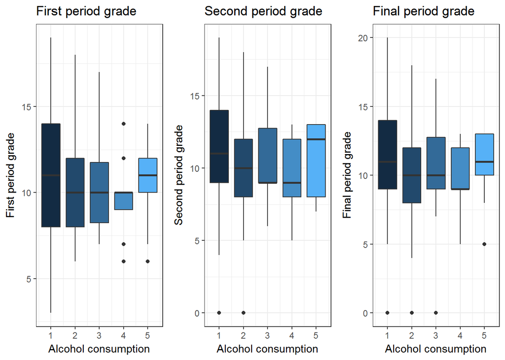

```r
boxplot1 <- ggplot(df, aes(x=Dalc, y=G1, fill=Dalc))+
  geom_boxplot(aes(group = Dalc))+
  theme_bw()+
  xlab("Alcohol consumption")+
  ylab("First period grade")+
  ggtitle("First period grade") + theme(legend.position = "none")

boxplot2 <- ggplot(df, aes(x=Dalc, y=G2, fill=Dalc))+
  geom_boxplot(aes(group = Dalc))+
  theme_bw()+
  xlab("Alcohol consumption")+
  ylab("Second period grade")+
  ggtitle("Second period grade") + theme(legend.position = "none")

boxplot3 <- ggplot(df, aes(x=Dalc, y=G3, fill=Dalc))+
  geom_boxplot(aes(group = Dalc))+
  theme_bw()+
  xlab("Alcohol consumption")+
  ylab("Final period grade")+
  ggtitle("Final period grade") + theme(legend.position = "none")

grid.arrange(boxplot1, boxplot2, boxplot3, ncol = 3)
```

There seems to be many outliers in G3’s data.

## Comparing mean grades of G1, G2 and G3 with respect to Dalc

We will now compare the mean grades of G1, G2 and G3 with respect to the workday alcohol consumption levels (Dalc). Our main focus will again be G3. When you hover over the bar chart, please ignore the Dalc values. The values of Dalc for each group of bar chart is supposed to be the same.

```r
toPlot <- group_by(df, Dalc) %>% summarize(G1Mean = mean(G1), G2Mean = mean(G2), G3Mean = mean(G3))
toPlot.m <- melt(toPlot,id.var="Dalc")
colnames(toPlot.m)[3] <- "MeanGradeMarks"
ggplotly(ggplot(toPlot.m, aes(x=Dalc, y=MeanGradeMarks, fill=variable)) + geom_bar(position="dodge",stat="identity") + ggtitle("Workday Alcohol Consumption Levels (Dalc) against Mean Grade Marks"))
```

[interactive chart not shown]

It seems that the mean grades for G3 for those that consume alcohol at the lowest level (1) are quite close to those that consume alcohol at the highest level (5). Why is that so?

```r
table(df$Dalc, df$G3)
```

```
##
##      0  4  5  6  7  8  9 10 11 12 13 14 15 16 17 18 19 20
##   1 26  0  3 13  6 18 17 36 35 20 19 22 29 12  4 10  5  1
##   2 11  1  2  2  1 10  4 12  8  7  4  4  4  2  1  2  0  0
##   3  1  0  0  0  2  2  4  7  1  2  3  1  0  2  1  0  0  0
##   4  0  0  1  0  0  1  3  0  1  1  2  0  0  0  0  0  0  0
##   5  0  0  1  0  0  1  0  1  2  1  3  0  0  0  0  0  0  0
```

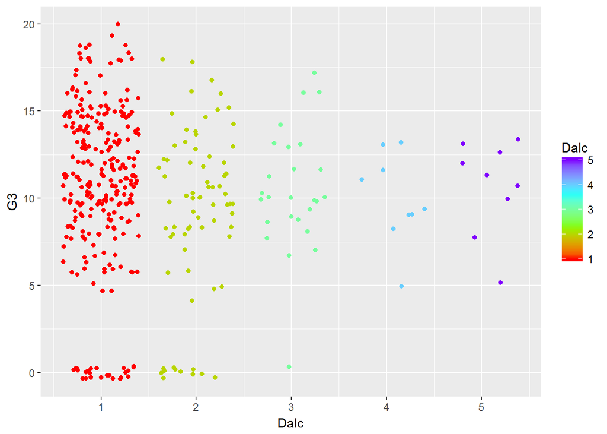

```r
ggplot(df, aes(x=Dalc, y=G3, color = Dalc))+ geom_jitter() + scale_colour_gradientn(colours=rainbow(4))
```

Looks like that there is an abnormal number of students who have a Dalc of 1 and have G3 values of 0. This has decreased the mean value of G3 significantly when Dalc = 1. However, we cannot remove these values because we cannot be sure if those values are errors or the truth. There may be other factors unrelated to alcohol consumption which is affecting the students’ grades.

## Associating Family Relationship With Alcohol Consumption Levels

```r
toPlot2 <- group_by(df, famrel) %>% summarize(WorkdayAlcoholConsumption = mean(Dalc), WeekendAlcoholConsumption = mean(Walc))
toPlot2.m <- melt(toPlot2, id.var = "famrel")
colnames(toPlot2.m)[3] <- "AlcoholMean"

ggplotly(ggplot(toPlot2.m, aes(x=famrel, y=AlcoholMean, color = variable)) + geom_line() + geom_point() + ggtitle("Family Relationship against Mean Alcohol Consumption"))
```

[interactive chart not shown]

As we can see, the general trend is a decreasing trend as family relationship (famrel) increases. This would infer that when students have a close relationship with their family members, their levels of alcohol consumption (no matter if it is a workday alcohol consumption or weekend alcohol consumption) will decrease.

## Associating Relationship Status With Alcohol Consumption Levels

```r
toPlot3 <- group_by(df, romantic) %>% summarize(WorkdayAlcocholConsumption = mean(Dalc), WeekendAlcoholConsumption = mean(Walc))
toPlot3.m <- melt(toPlot3, id.var = "romantic")
colnames(toPlot3.m)[1] <- "RelationshipStatus"
colnames(toPlot3.m)[3] <- "AlcoholMean"
toPlot3.m[1] <- apply(toPlot3.m[1], 1, function(x) {ifelse(x == 'yes', 'Couple', 'Single')})
ggplotly(ggplot(toPlot3.m, aes(x=variable, y=AlcoholMean, fill=RelationshipStatus)) + geom_bar(position="dodge",stat="identity") + ggtitle("Relationship Status against Mean Alcohol Consumption"))
```

[interactive chart not shown]

The level of alcohol consumption for students who have romantic partners (Couple) are similar to those without romantic partners (Single). There is only a 0.03 difference between the mean alcohol level consumption between couples and singles in both workday alcohol consumption and weekend alcohol consumption with couples being the leader in the former and singles being the leader in the latter.  
This could mean that we should not take romantic relationships in high school to be as intimate as adult relationships. From our dataset, there is no significant difference in alcohol consumption levels with relationship status.

## Associating Health With Alcohol Consumption Levels

```r
toPlot4 <- group_by(df, health) %>% summarize(WorkdayAlcoholConsumption = mean(Dalc), WeekendAlcoholConsumption = mean(Walc))
toPlot4.m <- melt(toPlot4, id.var = "health")
colnames(toPlot4.m)[3] <- "AlcoholMean"

ggplotly(ggplot(toPlot4.m, aes(x=health, y=AlcoholMean, color = variable)) + geom_line() + geom_point() + ggtitle("Health against Mean Alcohol Consumption"))
```

[interactive chart not shown]